# Data visualization with R coronavirus and ggplot2 Packages

05 March, 2020

# Coronavirus

As we all know the coronavirus is a current issue that concerns all humanity because of its gravity. Wanting to know more, I found a package in CRAN that helped me understand the spread of the disease globally. Although for many it may seem like a rudimentary table of daily case records, I found in this simple data set an opportunity to do what I like most - graphics - and to share with those people who want to venture to use **R** something of what I have learned with `ggplot`. Of course, without neglecting how serious this disease is and how it has been its temporal and spatial evolution on the planet. Well, as the saying goes:

> *A picture is worth a thousand words.*

Johns Hopkins University Center for Systems Science and Engineering (JHU CCSE) has released a package at CRAN which provides a daily summary of the **Coronavirus (COVID-19)** cases by state/province. The package is available at https://cran.r-project.org/web/packages/coronavirus/index.html. Below, I’ll show some simple analysis with this dataset with the help of *ggplot2* in *R*, my aim for next posts is to show you how to create animated plots with *gganimate* package.

The main gist of the process is to show how coronavirus is spread in the World nowadays, and how the cases in each country are increasing. To get started, you’ll need to download coronavirus from Github using the `devtools` package:

```r
# *************** Install package ***************

if (!require(devtools)) {
    install.packages("devtools")
}
if (!require(coronavirus)) {
  devtools::install_github(" RamiKrispin/coronavirus")
}
```

In addition to this package, I’ll also use `dplyr` and `magrittr` for data manipulation, `ggplot2` for plotting, and `maps` for manipulate geographical data.

```r
library(coronavirus)  # The 2019 Novel Coronavirus COVID-19 (2019-nCoV) Dataset
library(dplyr)        # A Grammar of Data Manipulation
library(magrittr)     # A Forward-Pipe Operator for R
library(maps)         # Draw Geographical Maps
library(ggplot2)      # Create Elegant Data Visualisations Using the Grammar of Graphics
```

## COVID-19 spread evolution around the Globe

When loading the `library(coronavirus)` we get the dataset which contains the daily summary of Coronavirus cases (confirmed, death, and recovered), by state/province for some countries as seen below:

```r
library(knitr) # A General-Purpose Package for Dynamic Report Generation in R
DT::datatable(coronavirus, rownames = FALSE)
```

| Province.State | Country.Region | Lat | Long | date | cases | type |
| --- | --- | --- | --- | --- | --- | --- |
|  | Japan | 35.6762 | 139.6503 | 2020-01-22 | 2 | confirmed |
|  | South Korea | 37.5665 | 126.978 | 2020-01-22 | 1 | confirmed |
|  | Thailand | 13.7563 | 100.5018 | 2020-01-22 | 2 | confirmed |
| Anhui | Mainland China | 31.82571 | 117.2264 | 2020-01-22 | 1 | confirmed |
| Beijing | Mainland China | 40.18238 | 116.4142 | 2020-01-22 | 14 | confirmed |
| Chongqing | Mainland China | 30.05718 | 107.874 | 2020-01-22 | 6 | confirmed |
| Fujian | Mainland China | 26.07783 | 117.9895 | 2020-01-22 | 1 | confirmed |
| Guangdong | Mainland China | 23.33841 | 113.422 | 2020-01-22 | 26 | confirmed |
| Guangxi | Mainland China | 23.82908 | 108.7881 | 2020-01-22 | 2 | confirmed |
| Guizhou | Mainland China | 26.81536 | 106.8748 | 2020-01-22 | 1 | confirmed |

[output cut: 1497 more lines]

Now we are going to calculate the quantity of cases confirmed, death, and recovered until the last time dataset was updated for each country. Grouping data by Country.Region, Province.State, Lat, Long and type and adding up the cases, we have:

```r
coronavirus_data <-
coronavirus %>%
  group_by(Country.Region, Province.State, Lat, Long, type) %>%
  summarise(total = sum(cases)) %>%
  rename(Country = Country.Region)

coronavirus_data %>% head() %>% kable()
```

| Country | Province.State | Lat | Long | type | total |
| --- | --- | --- | --- | --- | --- |
| Australia | New South Wales | -33.8688 | 151.2093 | confirmed | 4 |
| Australia | New South Wales | -33.8688 | 151.2093 | recovered | 4 |
| Australia | Queensland | -27.4698 | 153.0251 | confirmed | 5 |
| Australia | South Australia | -34.9285 | 138.6007 | confirmed | 2 |
| Australia | Victoria | -37.8136 | 144.9631 | confirmed | 4 |
| Australia | Victoria | -37.8136 | 144.9631 | recovered | 4 |

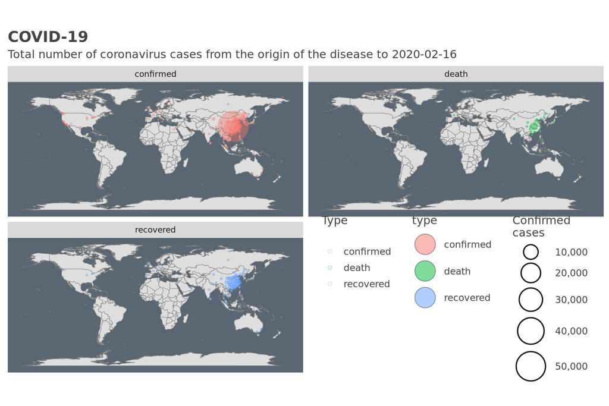

```r
# CREATE THEME
theme.maptheeme <-
  theme(text = element_text(family = "Gill Sans", color = "#444444")) +
  theme(plot.title = element_text(size = 16, face = "bold")) +
  theme(plot.subtitle = element_text(size = 12)) +
  theme(panel.grid = element_blank()) +
  theme(axis.text = element_blank()) +
  theme(axis.ticks = element_blank()) +
  theme(axis.title = element_blank()) +
  theme(legend.background = element_blank()) +
  theme(legend.key = element_blank()) +
  theme(legend.title = element_text(size = 12)) +
  theme(legend.text = element_text(size = 10)) +
  theme(panel.background = element_rect(fill = "#596673")) +
  theme(panel.grid = element_blank())

map.world <- map_data("world")  # Here we are obtaining the worldmap data, borders, countries, etc.

ggplot() +
  geom_polygon(data = map.world, aes(x = long, y = lat, group = group),
               fill = "#DEDEDE",colour = "#818181", size = 0.2) +   # World map
  geom_point(data = coronavirus_data,
             aes(x = Long, y = Lat, size = total, fill = type, color = type),
             shape = 21, stroke =0.4, alpha = 0.4) +                 # Coronavirus
  facet_wrap(facets = ~type, ncol = 2) +                            # Facet
  scale_size_continuous(range = c(.7,15),
                        labels = scales::comma_format()) +
  labs(x="", y="", title = "COVID-19",
       subtitle = paste("Total number of coronavirus cases from the origin of the disease to",
                        max(coronavirus$date)),
       size = "Confirmed \ncases" , color = "Type\n") +                                # Aesthetics
  guides(fill = guide_legend(override.aes = list(size=10, alpha = 0.5)),
         size = guide_legend(override.aes = list(alpha = 0.9, stroke = 1))) +
  coord_fixed() +
  theme.maptheeme +
  theme(plot.title = element_text(face = "bold"),
        legend.position = c(0.75, 0.25),
        legend.direction = "vertical",
        legend.box = "horizontal")
```

[figure not shown]

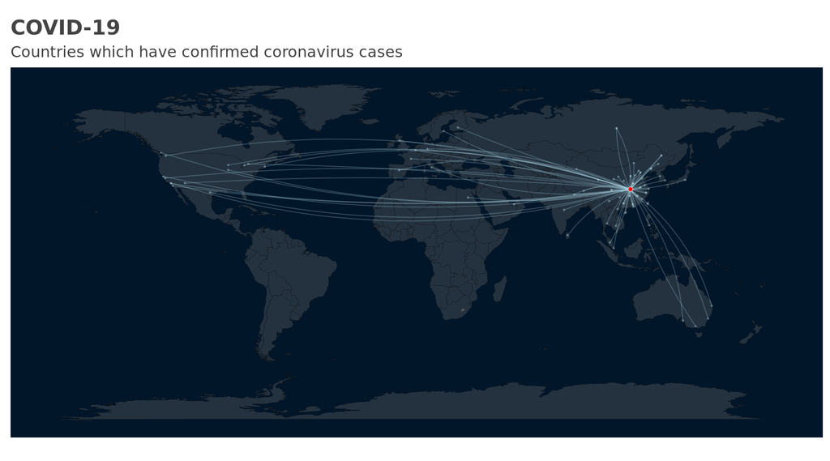

```r
Wuhan <-
data.frame(Province.State = "Hubei",
           Lat = 30.97564,
           Long = 112.2707)

migr_corona <-
coronavirus %>% filter(Province.State != "Hubei") %>%
  select(Lat, Long) %>% distinct() %>%
  mutate(curvature = runif(n(), min = -0.2, max = 0.2))

ggplot() +
  geom_polygon(data = map.world, aes(x = long, y = lat, group = group),
               fill="#767676", colour = "black", size = 0.05, alpha = 0.3) +
lapply(split(migr_corona, 1:nrow(migr_corona)), function(dat) {
    geom_curve(data = dat, aes(x=Wuhan$Long, y=Wuhan$Lat, xend=Long, yend=Lat),
               color= alpha("lightblue", 0.3),
               size=.3,
               curvature = dat["curvature"]) }) +
  geom_point(data=Wuhan,
             aes(x=Long, y=Lat),
             fill="red", shape = 21, stroke=0.2,
             color ="white", size=1.5) +
  geom_point(data=migr_corona,
             aes(x=Long, y=Lat),
             color =alpha("lightblue", 0.3),size=0.2) +
  coord_fixed() +
  guides(color=guide_legend(nrow = 3)) +
  labs(x="", y="", title = "COVID-19", subtitle = "Countries which have confirmed coronavirus cases",
       color = "") +
  #transition_reveal(along = date, keep_last = T) +
  theme.maptheeme +
  theme(plot.title = element_text(face = "bold"),
        legend.position = "bottom",
        panel.background = element_rect(fill = "#021629"))
```